# ISYE 6501

2022-10-12

# Submission HW4 | Fall 22

- Ashish Dhiman | ashish.dhiman@gatech.edu
- Abhinav Arun | aarun60@gatech.edu
- Anshit Verma | averma373@gatech.edu

*Analysis Notes are marked with Red header: #Analysis

## Question 11.1

## Part 1 : Stepwise Regression

```r
library(ggplot2)
library(qqplotr)
library(cowplot)
library(reshape2)
library(grid)
library(MASS)
library(glmnet)
#install.packages("car")
library(car)
```

```r
crime_data<-read.table(file = "./uscrime.txt", sep = "\t",header=TRUE)
head(crime_data)
```

|  | M | So | Ed | Po1 | Po2 | LF | M.F | Pop | NW | U1 | U2 | Wealth | Ineq | Prob | Time | Crime |
| --- | --- | --- | --- | --- | --- | --- | --- | --- | --- | --- | --- | --- | --- | --- | --- | --- |
| 1 | 15.1 | 1 | 9.1 | 5.8 | 5.6 | 0.510 | 95.0 | 33 | 30.1 | 0.108 | 4.1 | 3940 | 26.1 | 0.084602 | 26.2011 | 791 |
| 2 | 14.3 | 0 | 11.3 | 10.3 | 9.5 | 0.583 | 101.2 | 13 | 10.2 | 0.096 | 3.6 | 5570 | 19.4 | 0.029599 | 25.2999 | 1635 |
| 3 | 14.2 | 1 | 8.9 | 4.5 | 4.4 | 0.533 | 96.9 | 18 | 21.9 | 0.094 | 3.3 | 3180 | 25.0 | 0.083401 | 24.3006 | 578 |
| 4 | 13.6 | 0 | 12.1 | 14.9 | 14.1 | 0.577 | 99.4 | 157 | 8.0 | 0.102 | 3.9 | 6730 | 16.7 | 0.015801 | 29.9012 | 1969 |
| 5 | 14.1 | 0 | 12.1 | 10.9 | 10.1 | 0.591 | 98.5 | 18 | 3.0 | 0.091 | 2.0 | 5780 | 17.4 | 0.041399 | 21.2998 | 1234 |
| 6 | 12.1 | 0 | 11.0 | 11.8 | 11.5 | 0.547 | 96.4 | 25 | 4.4 | 0.084 | 2.9 | 6890 | 12.6 | 0.034201 | 20.9995 | 682 |

```r
dim(crime_data)
```

```
## [1] 47 16
```

```r
# Fitting the full model
# The full model has 15 independent variables
full_model <- lm(Crime ~., data = crime_data)
summary(full_model)
```

```
##
## Call:
## lm(formula = Crime ~ ., data = crime_data)
##
## Residuals:
##     Min      1Q  Median      3Q     Max
## -395.74  -98.09   -6.69  112.99  512.67
##
## Coefficients:
##               Estimate Std. Error t value Pr(>|t|)
## (Intercept) -5.984e+03  1.628e+03  -3.675 0.000893 ***
## M            8.783e+01  4.171e+01   2.106 0.043443 *
## So          -3.803e+00  1.488e+02  -0.026 0.979765
## Ed           1.883e+02  6.209e+01   3.033 0.004861 **
## Po1          1.928e+02  1.061e+02   1.817 0.078892 .
## Po2         -1.094e+02  1.175e+02  -0.931 0.358830
## LF          -6.638e+02  1.470e+03  -0.452 0.654654
## M.F          1.741e+01  2.035e+01   0.855 0.398995
## Pop         -7.330e-01  1.290e+00  -0.568 0.573845
## NW           4.204e+00  6.481e+00   0.649 0.521279
## U1          -5.827e+03  4.210e+03  -1.384 0.176238
## U2           1.678e+02  8.234e+01   2.038 0.050161 .
## Wealth       9.617e-02  1.037e-01   0.928 0.360754
## Ineq         7.067e+01  2.272e+01   3.111 0.003983 **
## Prob        -4.855e+03  2.272e+03  -2.137 0.040627 *
## Time        -3.479e+00  7.165e+00  -0.486 0.630708
## ---
## Signif. codes:  0 '***' 0.001 '**' 0.01 '*' 0.05 '.' 0.1 ' ' 1
##
## Residual standard error: 209.1 on 31 degrees of freedom
## Multiple R-squared:  0.8031, Adjusted R-squared:  0.7078
## F-statistic: 8.429 on 15 and 31 DF,  p-value: 3.539e-07
```

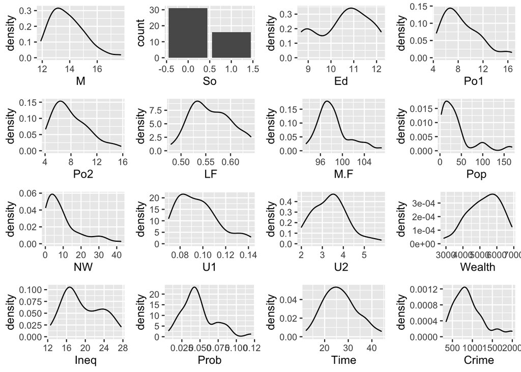

```r
### Data Distribution and Pairwise Corelation
my_plots <- lapply(names(crime_data), function(var_x){
  p <-
    ggplot(crime_data) +
    aes_string(var_x)
  if(var_x %in% list("So")) {
    p <- p + geom_bar()
  } else {
    p <- p + geom_density()
  }
})
plot_grid(plotlist = my_plots)
```

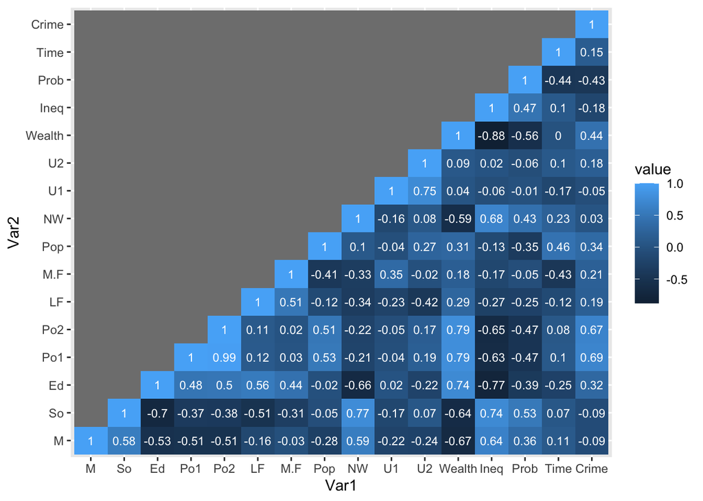

```r
### Correlation
cormat <- round(cor(crime_data),2)
cormat[upper.tri(cormat)] <- NA
melted_cormat <- melt(cormat)
# plotting the correlation heatmap
ggplot(data = melted_cormat, aes(x=Var1, y=Var2,
                                   fill=value)) +
geom_tile() +
geom_text(aes(Var1, Var2, label = value),
          color = "white", size = 3)
```

```r
#The "maximal" model is a linear regression model which assumes independent model errors and includes only main effects for the predictor variables.

#The "maximal" model is used as input for the stepAIC() function

# Stepwise regression model to choose the best model by AIC in a stepwise algorithm (shown with iterations)
step_model <- stepAIC(full_model, direction = "both")
```

```
## Start:  AIC=514.65
## Crime ~ M + So + Ed + Po1 + Po2 + LF + M.F + Pop + NW + U1 +
##     U2 + Wealth + Ineq + Prob + Time
##
##          Df Sum of Sq     RSS    AIC
## - So      1        29 1354974 512.65
## - LF      1      8917 1363862 512.96
## - Time    1     10304 1365250 513.00
## - Pop     1     14122 1369068 513.14
## - NW      1     18395 1373341 513.28
## - M.F     1     31967 1386913 513.74
## - Wealth  1     37613 1392558 513.94
## - Po2     1     37919 1392865 513.95
## <none>                1354946 514.65
## - U1      1     83722 1438668 515.47
## - Po1     1    144306 1499252 517.41
## - U2      1    181536 1536482 518.56
## - M       1    193770 1548716 518.93
## - Prob    1    199538 1554484 519.11
## - Ed      1    402117 1757063 524.86
## - Ineq    1    423031 1777977 525.42
##
## Step:  AIC=512.65
## Crime ~ M + Ed + Po1 + Po2 + LF + M.F + Pop + NW + U1 + U2 +
##     Wealth + Ineq + Prob + Time
##
##          Df Sum of Sq     RSS    AIC
## - Time    1     10341 1365315 511.01
## - LF      1     10878 1365852 511.03
## - Pop     1     14127 1369101 511.14
## - NW      1     21626 1376600 511.39
## - M.F     1     32449 1387423 511.76
## - Po2     1     37954 1392929 511.95
## - Wealth  1     39223 1394197 511.99
## <none>                1354974 512.65
## - U1      1     96420 1451395 513.88
## + So      1        29 1354946 514.65
## - Po1     1    144302 1499277 515.41
## - U2      1    189859 1544834 516.81
## - M       1    195084 1550059 516.97
```

[output cut: 118 more lines]

```
## + Wealth  1     26493 1426575 505.07
## - M.F     1    103159 1556227 505.16
## + Pop     1     16697 1436371 505.39
## + Po2     1     14148 1438919 505.47
## + So      1      9329 1443739 505.63
## + LF      1      4374 1448694 505.79
## + NW      1      3799 1449269 505.81
## + Time    1      2293 1450775 505.86
## - U1      1    127044 1580112 505.87
## - Prob    1    247978 1701046 509.34
## - U2      1    255443 1708511 509.55
## - M       1    296790 1749858 510.67
## - Ed      1    445788 1898855 514.51
## - Ineq    1    738244 2191312 521.24
## - Po1     1   1672038 3125105 537.93
```

```r
summary(step_model)
```

```
##
## Call:
## lm(formula = Crime ~ M + Ed + Po1 + M.F + U1 + U2 + Ineq + Prob,
##     data = crime_data)
##
## Residuals:
##     Min      1Q  Median      3Q     Max
## -444.70 -111.07    3.03  122.15  483.30
##
## Coefficients:
##             Estimate Std. Error t value Pr(>|t|)
## (Intercept) -6426.10    1194.61  -5.379 4.04e-06 ***
## M              93.32      33.50   2.786  0.00828 **
## Ed            180.12      52.75   3.414  0.00153 **
## Po1           102.65      15.52   6.613 8.26e-08 ***
## M.F            22.34      13.60   1.642  0.10874
## U1          -6086.63    3339.27  -1.823  0.07622 .
## U2            187.35      72.48   2.585  0.01371 *
## Ineq           61.33      13.96   4.394 8.63e-05 ***
## Prob        -3796.03    1490.65  -2.547  0.01505 *
## ---
## Signif. codes:  0 '***' 0.001 '**' 0.01 '*' 0.05 '.' 0.1 ' ' 1
##
## Residual standard error: 195.5 on 38 degrees of freedom
## Multiple R-squared:  0.7888, Adjusted R-squared:  0.7444
## F-statistic: 17.74 on 8 and 38 DF,  p-value: 1.159e-10
```

```r
#Final model at the end of stepwise regression model
final_model<-stepAIC(full_model, direction = "both",trace=FALSE)
summary(final_model)
```

```
##
## Call:
## lm(formula = Crime ~ M + Ed + Po1 + M.F + U1 + U2 + Ineq + Prob,
##     data = crime_data)
##
## Residuals:
##     Min      1Q  Median      3Q     Max
## -444.70 -111.07    3.03  122.15  483.30
##
## Coefficients:
##             Estimate Std. Error t value Pr(>|t|)
## (Intercept) -6426.10    1194.61  -5.379 4.04e-06 ***
## M              93.32      33.50   2.786  0.00828 **
## Ed            180.12      52.75   3.414  0.00153 **
## Po1           102.65      15.52   6.613 8.26e-08 ***
## M.F            22.34      13.60   1.642  0.10874
## U1          -6086.63    3339.27  -1.823  0.07622 .
## U2            187.35      72.48   2.585  0.01371 *
## Ineq           61.33      13.96   4.394 8.63e-05 ***
## Prob        -3796.03    1490.65  -2.547  0.01505 *
## ---
## Signif. codes:  0 '***' 0.001 '**' 0.01 '*' 0.05 '.' 0.1 ' ' 1
##
## Residual standard error: 195.5 on 38 degrees of freedom
## Multiple R-squared:  0.7888, Adjusted R-squared:  0.7444
## F-statistic: 17.74 on 8 and 38 DF,  p-value: 1.159e-10
```

```r
# Computing the Variance Inflation factor to see if multicolinearity issue exists in the final model
vif(final_model)
```

```
##        M       Ed      Po1      M.F       U1       U2     Ineq     Prob
## 2.131963 4.189684 2.560496 1.932367 4.360038 4.508106 3.731074 1.381879
```

# Observations/Inferences :

1. The initial full model has 15 independent predictor variables. Whereas , our final model output of the Stepwise Regression Model has 8 important predictor variables that minimizes the AIC value . These variables are evaluated on using the combination of forward selection and backward elimination methods iteratively. The lower the AIC value , the better the model as AIC value estimates the relative amount of information lost by a given model in an effort to estimate the actual model (Info Theory).
2. Another point to note is that the Multiple R-squared of the final model is 0.789 which is lower than the initial model which has a value of 0.8031 but this is the pitfall of R squared value i.e. It will always increases with the increase in the # of variables without any penalty/adjustment for model complexity/overfitting unlike AIC or Adjusted R-squared.
3. If we observe Adjusted R squared value , it is higher for our final model with 8 independent predictor variables , thus the final model is validated to be better than the initial model on the basis of Adjusted R squared value too.

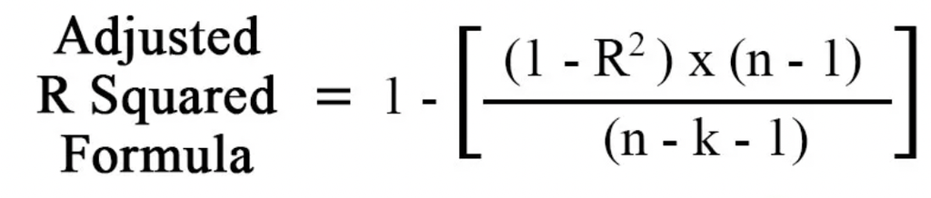

Based on the above formula , we can infer that the Adjusted R squared value decreases with the increase in # of independent variables(k) until and unless if there is a significant increase in the R squared value on adding a new variable. Thus both AIC and Adjusted R squared provide a technique for selecting simpler model which prevents overfitting.

4. Also , based on the correlation plot it could be seen that variables Wealth and Income Inequality are 2 highly correlated variables (-ve correlation), hence we should pick only 1 variable out of the 2. Same goes for Po1 and Po2. So , if we see our final model , it has just Ineq (Income Inequality) and Po1 (one out of each pair of correlated variables ) and thus our stepwise regression model handles it implicitly.
5. Since , the Variance Inflation factor for all the predictor variables in the final output is less than 5 , we can infer that the problem of multicollinearity also does not reside in our final model.

## Part 2: Lasso Regression

```r
crime_df = read.table("./uscrime.txt", sep="\t", header= TRUE)
dim(crime_df)
```

```
## [1] 47 16
```

```r
names(crime_df)
```

```
##  [1] "M"      "So"     "Ed"     "Po1"    "Po2"    "LF"     "M.F"    "Pop"
##  [9] "NW"     "U1"     "U2"     "Wealth" "Ineq"   "Prob"   "Time"   "Crime"
```

```r
x = as.matrix(crime_df[,names(crime_df) != "Crime"])
y = as.matrix(crime_df[,"Crime"])
dim(x)
```

```
## [1] 47 15
```

```r
dim(y)
```

```
## [1] 47  1
```

```r
fit <- glmnet(x, y, alpha = 1, nlambda = 20, standardize = TRUE)
```

```r
print(fit)
```

```
##
## Call:  glmnet(x = x, y = y, alpha = 1, nlambda = 20, standardize = TRUE)
##
##    Df  %Dev  Lambda
## 1   0  0.00 263.100
## 2   1 29.35 162.000
## 3   1 40.48  99.780
## 4   4 47.72  61.450
## 5   5 61.97  37.840
## 6   9 69.90  23.310
## 7  10 74.67  14.350
## 8  11 77.43   8.840
## 9  12 78.82   5.444
## 10 12 79.37   3.353
## 11 13 79.59   2.065
## 12 14 79.68   1.272
## 13 15 80.03   0.783
## 14 15 80.19   0.482
## 15 15 80.26   0.297
## 16 15 80.29   0.183
## 17 14 80.30   0.113
## 18 15 80.30   0.069
## 19 15 80.31   0.043
## 20 15 80.31   0.026
```

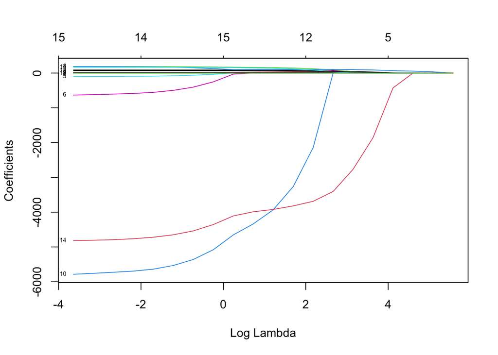

```r
plot(fit, xvar = "lambda", label = TRUE)
```

```r
cvfit <- cv.glmnet(x = x, y = y, alpha = 1, nlambda = 30, standardize = TRUE, type.measure = "mse", nfolds = 5)
```

Because we have only 47 points in the data, we don’t want fit too many models during the CV stage

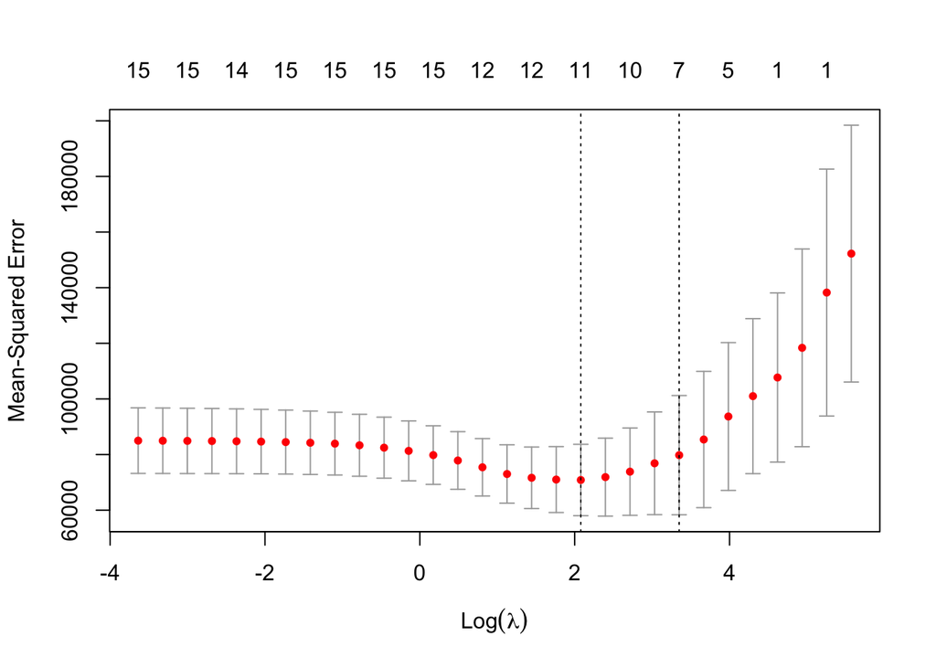

```r
plot(cvfit)
```

Above plot gives CV error against values of lambda. With increasing Lambda the weight of regularization factor increases, and therefore the model is encouraged, to select lower number of predictors.

```r
print (cvfit)
```

```
##
## Call:  cv.glmnet(x = x, y = y, type.measure = "mse", nfolds = 5, alpha = 1,      nlambda = 30, standardize = TRUE)
##
## Measure: Mean-Squared Error
##
##     Lambda Index Measure    SE Nonzero
## min  7.996    12   70854 12836      11
## 1se 28.484     8   79792 21426       7
```

Two special values along the 𝜆λ sequence are indicated by the vertical dotted lines. `lambda.min` is the value of λ that gives minimum mean cross-validated error, while `lambda.1se` is the value of λ that gives the most regularized model such that the cross-validated error is within one standard error of the minimum.

```r
coef(cvfit, s = "lambda.min")
```

```
## 16 x 1 sparse Matrix of class "dgCMatrix"
##                        s1
## (Intercept) -5.239682e+03
## M            7.385624e+01
## So           4.255598e+01
## Ed           1.303581e+02
## Po1          1.013264e+02
## Po2          .
## LF           .
## M.F          1.913240e+01
## Pop          .
## NW           7.375014e-01
## U1          -2.454538e+03
## U2           9.621363e+01
## Wealth       1.488733e-02
## Ineq         5.069567e+01
## Prob        -3.696033e+03
## Time         .
```

```r
coef(cvfit, s = "lambda.1se")
```

```
## 16 x 1 sparse Matrix of class "dgCMatrix"
##                        s1
## (Intercept) -2.721612e+03
## M            3.844127e+01
## So           .
## Ed           1.033432e+01
## Po1          9.724708e+01
## Po2          .
## LF           .
## M.F          1.833844e+01
## Pop          .
## NW           5.845563e-02
## U1           .
## U2           .
## Wealth       .
## Ineq         2.417506e+01
## Prob        -2.422223e+03
## Time         .
```

```r
cvfit$lambda.1se
```

```
## [1] 28.48367
```

```r
fit_1se <- glmnet(x, y, alpha = 1, lambda = cvfit$lambda.1se, standardize = TRUE)
coef(fit_1se)
```

```
## 16 x 1 sparse Matrix of class "dgCMatrix"
##                        s0
## (Intercept) -2.722551e+03
## M            3.867356e+01
## So           .
## Ed           1.024237e+01
## Po1          9.737255e+01
## Po2          .
## LF           .
## M.F          1.830572e+01
## Pop          .
## NW           9.167601e-03
## U1           .
## U2           .
## Wealth       .
## Ineq         2.422883e+01
## Prob        -2.415927e+03
## Time         .
```

```r
fit_min <- glmnet(x, y, alpha = 1, lambda = cvfit$lambda.min, standardize = TRUE)
coef(fit_min)
```

```
## 16 x 1 sparse Matrix of class "dgCMatrix"
##                        s0
## (Intercept) -5.234338e+03
## M            7.363622e+01
## So           4.316279e+01
## Ed           1.298784e+02
## Po1          1.012984e+02
## Po2          .
## LF           .
## M.F          1.917449e+01
## Pop          .
## NW           7.463892e-01
## U1          -2.436905e+03
## U2           9.568036e+01
## Wealth       1.500391e-02
## Ineq         5.061281e+01
## Prob        -3.702408e+03
## Time         .
```

```r
predict_min = predict(fit_min, newx = x, s = "lambda.min")
predict_1se = predict(fit_1se, newx = x, s = "lambda.1se")
```

```r
rmse_func = function(true,predicted){
  (mean((true-predicted)^2))**0.5
}
```

```r
rmse_func(true=y,predicted = predict_min)
```

```
## [1] 180.3211
```

```r
rmse_func(true=y,predicted = predict_1se)
```

```
## [1] 221.3399
```

## Part 3 : ElasticNet Regression

- Elastic net is a combination of both Lasso and Ridge regression. It uses both L1 and L2 penalty to restrict the regression solution.
- It involves two hyperparameters - Lambda and Alpha.
- Alpha is used to give direction between Ridge and Lasso. Alpha = 0 is Ridge and Alpha = 1 is Lasso.
- Lambda is amount of penalty in the regression.

```r
data = read.table("./uscrime.txt", sep="\t", header=TRUE)
head(data)
```

|  | M | So | Ed | Po1 | Po2 | LF | M.F | Pop | NW | U1 | U2 | Wealth | Ineq | Prob | Time | Crime |
| --- | --- | --- | --- | --- | --- | --- | --- | --- | --- | --- | --- | --- | --- | --- | --- | --- |
| 1 | 15.1 | 1 | 9.1 | 5.8 | 5.6 | 0.510 | 95.0 | 33 | 30.1 | 0.108 | 4.1 | 3940 | 26.1 | 0.084602 | 26.2011 | 791 |
| 2 | 14.3 | 0 | 11.3 | 10.3 | 9.5 | 0.583 | 101.2 | 13 | 10.2 | 0.096 | 3.6 | 5570 | 19.4 | 0.029599 | 25.2999 | 1635 |
| 3 | 14.2 | 1 | 8.9 | 4.5 | 4.4 | 0.533 | 96.9 | 18 | 21.9 | 0.094 | 3.3 | 3180 | 25.0 | 0.083401 | 24.3006 | 578 |
| 4 | 13.6 | 0 | 12.1 | 14.9 | 14.1 | 0.577 | 99.4 | 157 | 8.0 | 0.102 | 3.9 | 6730 | 16.7 | 0.015801 | 29.9012 | 1969 |
| 5 | 14.1 | 0 | 12.1 | 10.9 | 10.1 | 0.591 | 98.5 | 18 | 3.0 | 0.091 | 2.0 | 5780 | 17.4 | 0.041399 | 21.2998 | 1234 |
| 6 | 12.1 | 0 | 11.0 | 11.8 | 11.5 | 0.547 | 96.4 | 25 | 4.4 | 0.084 | 2.9 | 6890 | 12.6 | 0.034201 | 20.9995 | 682 |

```r
x = as.matrix(data[, 1:ncol(data)-1])
y = data[,"Crime"]
```

```r
x = scale(x)
```

### Train Test Split

```r
n=nrow(data)
train_rows <- sample(1:n, .8*n, replace = F)

x.train <- x[train_rows,]
y.train <- y[train_rows]

x.test <- x[-train_rows,]
y.test <- y[-train_rows]
```

- Splitting the data to get a value of MSE for deciding a value of alpha.

### Estimating Lambda and Alpha - hyperparameters

```r
models <- list()
for (i in 0:20) {
  name <- paste0("alpha", i/20)

  models[[name]] <-
    cv.glmnet(as.matrix(x.train), as.matrix(y.train), alpha=i/20, family="gaussian", nfold = 5)
}
```

- We are fixing the value of alpha and using cross validation for find the value of lambda which minimizes the value of MSE - our metric for validation.
- We find a minimum value of lambda which minimizes the MSE and another value of lambda one standard deviation apart as it is more practical. We are accepting some performance loss and incorporating more bias in the model.

```r
results <- data.frame()
for (i in 0:20) {
  name <- paste0("alpha", i/20)

  ## Use each model to predict 'y' given the Testing dataset
  predicted <- predict(models[[name]],
                       s=models[[name]]$lambda.1se, newx=x.test)

  ## Calculate the Mean Squared Error...
  mse <- mean((y.test - predicted)^2)

  ## Store the results
  temp <- data.frame(alpha=i/20, mse=mse, name=name)
  results <- rbind(results, temp)
}
```

- After we have selected our lambda, we predict on the test data for getting the value of alpha.
- Alpha is the parameter for deciding between ridge (L2 norm) penalty and lasso (L1 penalty) penalty.

```r
print(results)
```

```
##    alpha       mse      name
## 1   0.00 123592.89    alpha0
## 2   0.05 105742.02 alpha0.05
## 3   0.10  91081.90  alpha0.1
## 4   0.15  90570.88 alpha0.15
## 5   0.20  93178.64  alpha0.2
## 6   0.25  93058.06 alpha0.25
## 7   0.30  91530.80  alpha0.3
## 8   0.35  89668.74 alpha0.35
## 9   0.40  94249.62  alpha0.4
## 10  0.45 165148.65 alpha0.45
## 11  0.50 181316.24  alpha0.5
## 12  0.55  92675.95 alpha0.55
## 13  0.60  94546.74  alpha0.6
## 14  0.65 281307.62 alpha0.65
## 15  0.70 148438.36  alpha0.7
## 16  0.75 146834.01 alpha0.75
## 17  0.80 168628.84  alpha0.8
## 18  0.85  95742.36 alpha0.85
## 19  0.90 206472.32  alpha0.9
## 20  0.95  99646.67 alpha0.95
## 21  1.00  96434.72    alpha1
```

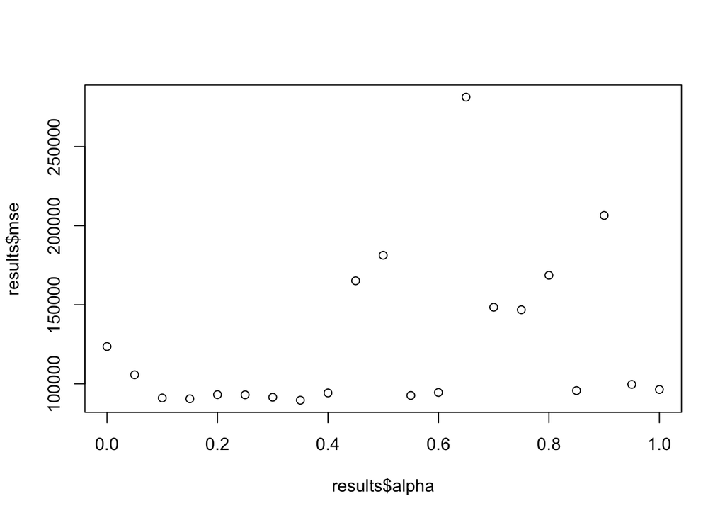

```r
plot(results$alpha, results$mse)
```

```r
results[which.min(results$mse),]
```

|  | alpha | mse | name |
| --- | --- | --- | --- |
| 8 | 0.35 | 89668.74 | alpha0.35 |

——– DO NOT INCLUDE AFTER THIS LINE ———

```r
library(MASS)
library(caret)
custom <- trainControl(method = "repeatedcv", number = 10, repeats = 5, verboseIter = TRUE)
```

```r
set.seed(1234)
en <- train(x = x.train, y = y.train,
            method='glmnet',
            tuneGrid =expand.grid(alpha=seq(0,1,length=10),
                                  lambda = seq(0.0001,0.2,length=5)),
            trControl=custom)
en
```

```
## glmnet
##
## 37 samples
## 15 predictors
##
## No pre-processing
## Resampling: Cross-Validated (10 fold, repeated 5 times)
## Summary of sample sizes: 33, 34, 33, 33, 33, 34, ...
## Resampling results across tuning parameters:
##
##   alpha      lambda    RMSE      Rsquared   MAE
##   0.0000000  0.000100  243.1612  0.5770341  203.1539
##   0.0000000  0.050075  243.1612  0.5770341  203.1539
##   0.0000000  0.100050  243.1612  0.5770341  203.1539
##   0.0000000  0.150025  243.1612  0.5770341  203.1539
##   0.0000000  0.200000  243.1612  0.5770341  203.1539
##   0.1111111  0.000100  256.1896  0.5689300  210.8641
##   0.1111111  0.050075  256.1896  0.5689300  210.8641
##   0.1111111  0.100050  256.1896  0.5689300  210.8641
##   0.1111111  0.150025  256.1896  0.5689300  210.8641
##   0.1111111  0.200000  256.2069  0.5688754  210.9024
##   0.2222222  0.000100  256.2550  0.5719020  210.5060
##   0.2222222  0.050075  256.2550  0.5719020  210.5060
##   0.2222222  0.100050  256.2629  0.5718791  210.5287
##   0.2222222  0.150025  256.2464  0.5705291  210.7073
##   0.2222222  0.200000  256.2344  0.5691203  210.8919
##   0.3333333  0.000100  256.3783  0.5726938  210.4729
##   0.3333333  0.050075  256.3783  0.5726938  210.4729
##   0.3333333  0.100050  256.2798  0.5720733  210.5237
##   0.3333333  0.150025  256.2417  0.5706459  210.6929
##   0.3333333  0.200000  256.2293  0.5692493  210.8701
##   0.4444444  0.000100  256.4520  0.5727549  210.5012
##   0.4444444  0.050075  256.4520  0.5727549  210.5012
##   0.4444444  0.100050  256.2692  0.5721818  210.5119
##   0.4444444  0.150025  256.2430  0.5707379  210.6831
##   0.4444444  0.200000  256.2292  0.5693700  210.8476
##   0.5555556  0.000100  256.4284  0.5727451  210.4936
##   0.5555556  0.050075  256.4284  0.5727451  210.4936
##   0.5555556  0.100050  256.2721  0.5722418  210.5054
##   0.5555556  0.150025  256.2454  0.5708182  210.6729
```

[output cut: 9 more lines]

```
##   0.7777778  0.150025  256.2487  0.5709617  210.6611
##   0.7777778  0.200000  256.2100  0.5697417  210.7797
##   0.8888889  0.000100  256.1719  0.5733789  210.3120
##   0.8888889  0.050075  256.1719  0.5733789  210.3120
##   0.8888889  0.100050  256.2480  0.5723703  210.4817
##   0.8888889  0.150025  256.2359  0.5710431  210.6337
##   0.8888889  0.200000  256.2065  0.5698334  210.7664
##   1.0000000  0.000100  256.1371  0.5728649  210.3441
##   1.0000000  0.050075  256.1371  0.5728649  210.3441
##   1.0000000  0.100050  256.2152  0.5722457  210.4784
##   1.0000000  0.150025  256.2133  0.5711534  210.6062
##   1.0000000  0.200000  256.1911  0.5699145  210.7395
##
## RMSE was used to select the optimal model using the smallest value.
## The final values used for the model were alpha = 0 and lambda = 0.2.
```

```r
mean(en$resample$RMSE)
```

```
## [1] 243.1612
```

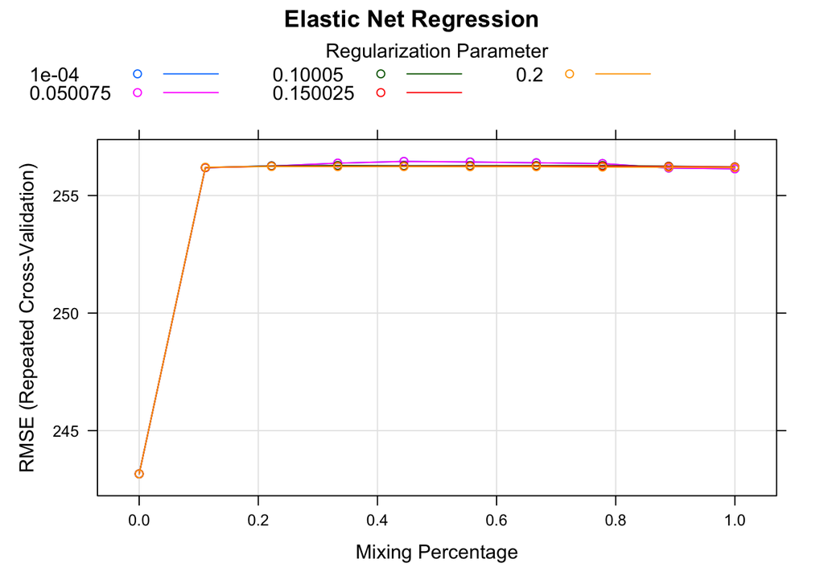

```r
plot(en, main = "Elastic Net Regression")
```

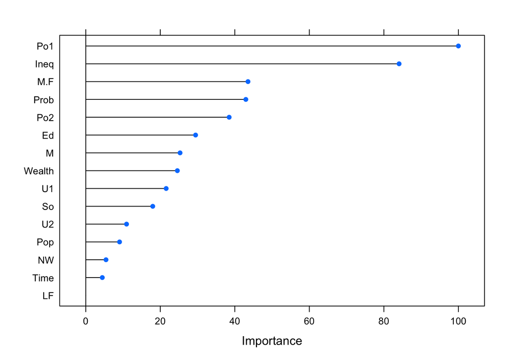

```r
plot(varImp(en,scale=TRUE))
```